# Post 1 - Probability Theory and Random Variables

- Show All Code
- Hide All Code
- View Source

code

data visualization

Author

Charan Teja Chelle

Published

September 15, 2023

# Introduction:

Two fundamental ideas in the wide field of machine learning - Random Variables and Probability Theory, pave way for reliable algorithms and accurate prediction, mitigating uncertainty to maximum possible extent. In this blog post, we will delve deeper into the core principles of these concepts and take a loot at their significance and relevance in current industry.

## Probability Theory

Probability theory provides a consistent framework for the quantification and manipulation of uncertainty with discrete and continuous probability distributions. It also extends its arms into Bayesian inference and Conditional probability, which are the backbone of probabilistic modeling.

## Random Variables

Random variables (discrete and continuous) assume the numerical value of all possible outcomes of an experiment, serving as a bridge between probability theory and data.

# Code:

## Code Sample - 1

This is a code sample that involves generating random variables and computing probabilities. A six-sided die is rolled 20 times (input) and probabilities of each outcome is calculated and displayed accordingly (output)

```python
import random

# Generating a Random Variable - Rolling a six-sided die
def roll_die():
    return random.randint(1, 6)

# Simulating an Experiment - Rolling a six-sided die 20 times
number_of_rolls = 20
all_rolls = [roll_die() for _ in range(number_of_rolls)]

# Computing Probability Distribution
def compute_probability(dice_outcomes):
    probabilities = {i: dice_outcomes.count(i) / len(dice_outcomes) for i in set(dice_outcomes)}
    return probabilities

# Displaying Results
print(f"Simulated Rolls: {all_rolls}")
print("\nProbability Distribution:")
for outcome, probability in compute_probability(all_rolls).items():
    print(f"Outcome {outcome}: Probability {probability:.2f}")
```

```
Simulated Rolls: [2, 4, 1, 6, 1, 5, 3, 3, 2, 6, 1, 4, 4, 1, 2, 4, 5, 1, 5, 1]

Probability Distribution:
Outcome 1: Probability 0.30
Outcome 2: Probability 0.15
Outcome 3: Probability 0.10
Outcome 4: Probability 0.20
Outcome 5: Probability 0.15
Outcome 6: Probability 0.10
```

## Code Sample - 2

This relatively complex code sample deals with conditional probability where ‘probability of playing cricket given the weather’ is already declared; and weather conditions for 20 days are simulated, which serves as input; output will be finding cricket playing possibilities for 20 days, backed with the data visualization table stating ‘weather conditions’ on the X-axis and ‘cricket playing possibilities’ on Y-axis with scattered points plotting conditional probability.

```
Simulated Weather probabilities for 20 days: [2 1 0 0 0 0 0 0 0 1 2 1 2 0 1 0 2 1 0 0]

Resultant Cricket playing probabilities for 20 days: [1, 1, 1, 1, 1, 1, 1, 1, 0, 1, 0, 1, 0, 1, 1, 1, 1, 1, 1, 1]
```

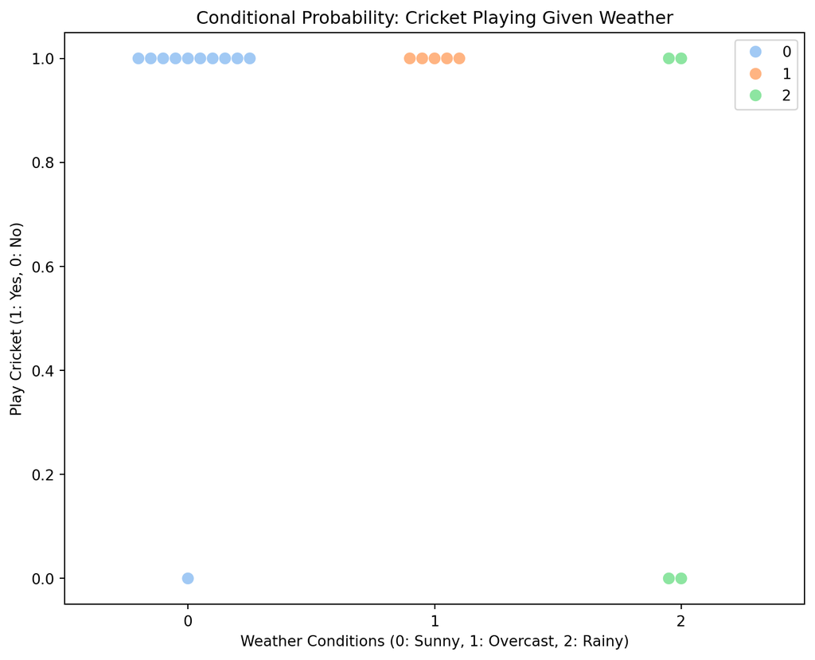

```python
import numpy as np
import matplotlib.pyplot as plt
import seaborn as sns

# Simulating Data - Weather and Cricket Playing
np.random.seed(45)

# Input: Simulating weather conditions (0: Sunny, 1: Overcast, 2: Rainy) for 20 days
weather_conditions = np.random.choice([0, 1, 2], size=20, p=[0.5, 0.2, 0.3])

# Conditional Probability - Probability of playing cricket given the weather
prob_play_cricket_given_sunny = 0.9
prob_play_cricket_given_overcast = 0.95
prob_play_cricket_given_rainy = 0.6

play_cricket = []

for weather in weather_conditions:
    if weather == 0:
        play_cricket.append(np.random.choice([1, 0], p=[prob_play_cricket_given_sunny, 1 - prob_play_cricket_given_sunny]))
    elif weather == 1:
        play_cricket.append(np.random.choice([1, 0], p=[prob_play_cricket_given_overcast, 1 - prob_play_cricket_given_overcast]))
    else:
        play_cricket.append(np.random.choice([1, 0], p=[prob_play_cricket_given_rainy, 1 - prob_play_cricket_given_rainy]))

# Displaying Results
print(f"Simulated Weather probabilities for 20 days: {weather_conditions}")
print(f"\nResultant Cricket playing probabilities for 20 days: {play_cricket}")

# Data Visualization using Seaborn and Matplotlib
plt.figure(figsize=(9, 7))

# Plotting Conditional Probability with Swarm Plot
sns.swarmplot(x=weather_conditions, y=play_cricket,hue=weather_conditions, palette="pastel", size=8)
plt.title('Conditional Probability: Cricket Playing Given Weather')
plt.xlabel('Weather Conditions (0: Sunny, 1: Overcast, 2: Rainy)')
plt.ylabel('Play Cricket (1: Yes, 0: No)')

# Displaying Results
plt.show()
```